# Analyze A/B Test Results

This project will assure you have mastered the subjects covered in the statistics lessons. We have organized the current notebook into the following sections:

- Introduction
- Part I - Probability
- Part II - A/B Test
- Part III - Regression

## Introduction

A/B tests are very commonly performed by data analysts and data scientists. For this project, you will be working to understand the results of an A/B test run by an e-commerce website. Your goal is to work through this notebook to help the company understand if they should:

- Implement the new webpage,
- Keep the old webpage, or
- Perhaps run the experiment longer to make their decision.

## Part I - Probability

To get started, let's import our libraries.

```python
import pandas as pd
import numpy as np
import random
import matplotlib.pyplot as plt
%matplotlib inline
#We are setting the seed to assure you get the same answers on quizzes as we set up
random.seed(42)
```

```python
df = pd.read_csv('ab_data.csv')
df.head()
```

|  | user_id | timestamp | group | landing_page | converted |
| --- | --- | --- | --- | --- | --- |
| 0 | 851104 | 2017-01-21 22:11:48.556739 | control | old_page | 0 |
| 1 | 804228 | 2017-01-12 08:01:45.159739 | control | old_page | 0 |
| 2 | 661590 | 2017-01-11 16:55:06.154213 | treatment | new_page | 0 |
| 3 | 853541 | 2017-01-08 18:28:03.143765 | treatment | new_page | 0 |
| 4 | 864975 | 2017-01-21 01:52:26.210827 | control | old_page | 1 |

**b.** Use the cell below to find the number of rows in the dataset.

```python
df.info()
```

```
<class 'pandas.core.frame.DataFrame'>
RangeIndex: 294478 entries, 0 to 294477
Data columns (total 5 columns):
 #   Column        Non-Null Count   Dtype
---  ------        --------------   -----
 0   user_id       294478 non-null  int64
 1   timestamp     294478 non-null  object
 2   group         294478 non-null  object
 3   landing_page  294478 non-null  object
 4   converted     294478 non-null  int64
dtypes: int64(2), object(3)
memory usage: 11.2+ MB
```

```python
df.shape[0]
```

```
294478
```

- Number of Rows in the Dataset = 294478

**c.** The number of unique users in the dataset.

```python
df.nunique()
```

```
user_id         290584
timestamp       294478
group                2
landing_page         2
converted            2
dtype: int64
```

```python
df.user_id.nunique()
```

```
290584
```

- Number of Unique Users = 290584

**d.** The proportion of users converted.

```python
df.converted.mean()
```

```
0.11965919355605512
```

**e.** The number of times when the "group" is `treatment` but "landing_page" is not a `new_page`.

```python
line_up = len(df.query('group == "treatment" and landing_page != "new_page"'))
line_up
```

```
1965
```

**f.** Do any of the rows have missing values?

```python
df.isnull().sum()
```

```
user_id         0
timestamp       0
group           0
landing_page    0
converted       0
dtype: int64
```

```python
# Remove the inaccurate rows, and store the result in a new dataframe df2
df_01 = df[(df.group == 'treatment') & (df.landing_page == 'new_page')]
df_02 = df[(df.group == 'control') & (df.landing_page == 'old_page')]
df12 = [df_01, df_02]
df2 = pd.concat(df12)
```

```python
# Double Check all of the incorrect rows were removed from df2 -
# Output of the statement below should be 0
df2[((df2['group'] == 'treatment') == (df2['landing_page'] == 'new_page')) == False].shape[0]
```

```
0
```

**a.** How many unique **user_id**s are in **df2**?

```python
df2.nunique()
```

```
user_id         290584
timestamp       290585
group                2
landing_page         2
converted            2
dtype: int64
```

**b.** There is one **user_id** repeated in **df2**. What is it?

```python
df2[df2.duplicated(['user_id'])]
```

|  | user_id | timestamp | group | landing_page | converted |
| --- | --- | --- | --- | --- | --- |
| 2893 | 773192 | 2017-01-14 02:55:59.590927 | treatment | new_page | 0 |

**c.** Display the rows for the duplicate **user_id**?

```python
df2[df2.duplicated(['user_id'], keep=False)]
```

|  | user_id | timestamp | group | landing_page | converted |
| --- | --- | --- | --- | --- | --- |
| 1899 | 773192 | 2017-01-09 05:37:58.781806 | treatment | new_page | 0 |
| 2893 | 773192 | 2017-01-14 02:55:59.590927 | treatment | new_page | 0 |

**d.** Remove **one** of the rows with a duplicate **user_id**, from the **df2** dataframe.

```python
# Remove one of the rows with a duplicate user_id..
# Hint: The dataframe.drop_duplicates() may not work in this case because the rows with duplicate user_id are not entirely identical.
df2 = df2.drop(axis=0, index=2893, inplace=False)
# Check again if the row with a duplicate user_id is deleted or not
df2[df2.duplicated(['user_id'])]
```

|  | user_id | timestamp | group | landing_page | converted |
| --- | --- | --- | --- | --- | --- |

```python
p_pop = df2.converted.mean()
p_pop
```

```
0.11959708724499628
```

**b.** Given that an individual was in the `control` group, what is the probability they converted?

```python
control_p = df2.query("group == 'control'").converted.mean()
control_p
```

```
0.1203863045004612
```

**c.** Given that an individual was in the `treatment` group, what is the probability they converted?

```python
Treat_p = df2.query("group == 'treatment'").converted.mean()
Treat_p
```

```
0.11880806551510564
```

```python
# Calculate the actual difference (obs_diff) between the conversion rates for the two groups.
```

```python
obs_diff = control_p - Treat_p
obs_diff
```

```
0.0015782389853555567
```

```python
obs_diffs = df2.query('group == "treatment"').converted.mean() - df2.query('group == "control"').converted.mean()
obs_diffs
```

```
-0.0015782389853555567
```

**Answer**

### The actual difference (obs_diff) between the conversion rates for the two groups Is too low

**d.** What is the probability that an individual received the new page?

```python
p_new = len(df2.query("landing_page == 'new_page'"))/len(df2)
p_new
```

```
0.5000619442226688
```

**e.** Consider your results from parts (a) through (d) above, and explain below whether the new `treatment` group users lead to more conversions.

#### The actual difference (obs_diff) between the conversion rates for the control and treatment group is too small while the individual received the new page is half of percent of the total we need more time to see if there any changes would happen upon the the differanc e between the two groups

**Answer** :

**a.** What is the **conversion rate** for $p_{new}$ under the null hypothesis?

```python
p_new = df2.converted.mean()
p_new
```

```
0.11959708724499628
```

**b.** What is the **conversion rate** for $p_{old}$ under the null hypothesis?

```python
p_old = df2['converted'].mean()
p_old
```

```
0.11959708724499628
```

**c.** What is $n_{new}$, the number of individuals in the treatment group?  
*Hint*: The treatment group users are shown the new page.

```python
n_new = df2.landing_page.value_counts()[0]
n_new
```

```
145310
```

**d.** What is $n_{old}$, the number of individuals in the control group?

```python
n_old = df2.landing_page.value_counts()[1]
n_old
```

```
145274
```

**e. Simulate Sample for the `treatment` Group**  
Simulate $n_{new}$ transactions with a conversion rate of $p_{new}$ under the null hypothesis.  
*Hint*: Use `numpy.random.choice()` method to randomly generate $n_{new}$ number of values.  
Store these $n_{new}$ 1's and 0's in the `new_page_converted` numpy array.

```python
# Simulate a Sample for the treatment Group
# randomly simulate new page landings using random.choice and p_new
new_page_converted = np.random.choice(2, size=n_new ,p=[p_new,1 - p_new])
new_page_converted.mean()
```

```
0.8805588053127795
```

**f. Simulate Sample for the `control` Group**  
Simulate $n_{old}$ transactions with a conversion rate of $p_{old}$ under the null hypothesis.  
Store these $n_{old}$ 1's and 0's in the `old_page_converted` numpy array.

```python
# Simulate a Sample for the control Group
old_page_converted = np.random.choice(2, size=n_old ,p=[p_old,1 - p_old])
old_page_converted.mean()
```

```
0.8810798904139764
```

**g.** Find the difference in the "converted" probability $(p{'}_{new}$ - $p{'}_{old})$ for your simulated samples from the parts (e) and (f) above.

```python
p_dif =  new_page_converted.mean() - old_page_converted.mean()
p_dif
```

```
-0.0005210851011968609
```

```python
# Sampling distribution
new_converted_simulation = np.random.binomial(n_new, p_new, 10000)/n_new
old_converted_simulation = np.random.binomial(n_old, p_old, 10000)/n_old
p_diffs = new_converted_simulation - old_converted_simulation
```

```python
p_diffs = np.array(p_diffs)
```

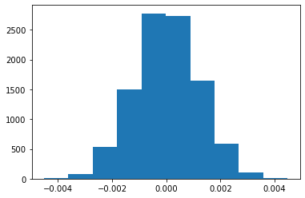

```python
plt.hist(p_diffs);
```

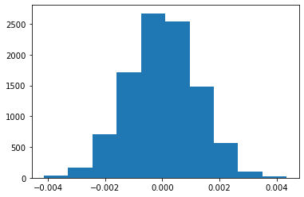

```python
nullvals = np.random.normal(0, p_diffs.std(), 10000)
plt.hist(nullvals);
```

**j.** What proportion of the **p_diffs** are greater than the actual difference observed in the `df2` data?

```python
actual_diff = df2.query("group == 'treatment'")['converted'].mean() - df2.query("group == 'control'")['converted'].mean()
actual_diff
```

```
-0.0015782389853555567
```

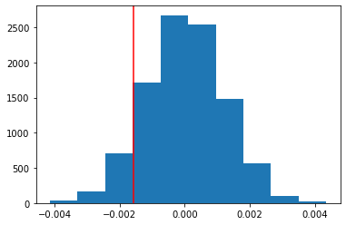

```python
plt.hist(nullvals);
plt.axvline(actual_diff, color = 'red');
```

```python
(nullvals > actual_diff).mean()
```

```
0.9071
```

**k.** Please explain in words what you have just computed in part **j** above.

- What is this value called in scientific studies?
- What does this value signify in terms of whether or not there is a difference between the new and old pages? *Hint*: Compare the value above with the "Type I error rate (0.05)".

**Answer**

- The above right line is where our observed statistics fall, the value I just computed in part j is the p-value,
- With a p-value of 0.90.* we conclude the difference in conversion rate between new page and old page does not appear to be significant. We fail to reject the null hypothesis concluding new page is not better than old page.
- The actual difference between new page and old page is negative, suggesting old page may be slightly better.
- We could also use a built-in to achieve similar results. Though using the built-in might be easier to code, the above portions are a walkthrough of the ideas that are critical to correctly thinking about statistical significance. Let n_old and n_new refer the the number of rows associated with the old page and new pages, respectively.

```python
import statsmodels.api as sm

# number of conversions with the old_page
convert_old = sum(df2.query("group == 'control'")['converted'])

# number of conversions with the new_page
convert_new = sum(df2.query("group == 'treatment'")['converted'])

# number of individuals who were shown the old_page
n_old = df2.landing_page.value_counts()[1]

# number of individuals who received new_page
n_new = df2.landing_page.value_counts()[0]
```

```python
convert_old, convert_new, n_old, n_new
```

```
(17489, 17264, 145274, 145310)
```

```python
import statsmodels.api as sm
# ToDo: Complete the sm.stats.proportions_ztest() method arguments
z_score, p_value = sm.stats.proportions_ztest([convert_old, convert_new], [n_old, n_new], alternative='smaller')
z_score, p_value
```

```
(1.3109241984234394, 0.9050583127590245)
```

```python
obs_diff = df2.query('group == "treatment"').converted.mean() - df2.query('group == "control"').converted.mean()
obs_diff
```

```
-0.0015782389853555567
```

```python
(p_diffs > obs_diff).mean()
```

```
0.9078
```

**Answer**  
The P Value (0.9051) is very Large by which We fail to reject the null hypothesis, While The z-score of 1.311 is less than critical value at 95% confidence interval, 1.960, so it falls within the confidence interval range of 95%. in another words The z-score and the p_value doesn't give us enough evidance to reject the Null Hypothesis as The Null being the converted rate of the old_page is the same or greater than the converted rate of the new_page. The p_value is 0.9051 and is higher than 0.05 significance level. That means we can not be confident with a 95% confidence level that the converted rate of the new_page is larger than the old_page

**Logistic Regression**

```python
df2.head()
```

|  | user_id | timestamp | group | landing_page | converted |
| --- | --- | --- | --- | --- | --- |
| 2 | 661590 | 2017-01-11 16:55:06.154213 | treatment | new_page | 0 |
| 3 | 853541 | 2017-01-08 18:28:03.143765 | treatment | new_page | 0 |
| 6 | 679687 | 2017-01-19 03:26:46.940749 | treatment | new_page | 1 |
| 8 | 817355 | 2017-01-04 17:58:08.979471 | treatment | new_page | 1 |
| 9 | 839785 | 2017-01-15 18:11:06.610965 | treatment | new_page | 1 |

**c.** Use **statsmodels** to instantiate your regression model on the two columns you created in part (b). above, then fit the model to predict whether or not an individual converts.

```python
import statsmodels.api as sm

df2['intercept'] = 1

df2[['control', 'treatment']] = pd.get_dummies(df2['group'])
df2.head()
```

|  | user_id | timestamp | group | landing_page | converted | intercept | control | treatment |
| --- | --- | --- | --- | --- | --- | --- | --- | --- |
| 2 | 661590 | 2017-01-11 16:55:06.154213 | treatment | new_page | 0 | 1 | 0 | 1 |
| 3 | 853541 | 2017-01-08 18:28:03.143765 | treatment | new_page | 0 | 1 | 0 | 1 |
| 6 | 679687 | 2017-01-19 03:26:46.940749 | treatment | new_page | 1 | 1 | 0 | 1 |
| 8 | 817355 | 2017-01-04 17:58:08.979471 | treatment | new_page | 1 | 1 | 0 | 1 |
| 9 | 839785 | 2017-01-15 18:11:06.610965 | treatment | new_page | 1 | 1 | 0 | 1 |

**d.** Provide the summary of your model below, and use it as necessary to answer the following questions.

```python
logitmod = sm.Logit(df2['converted'], df2[['intercept', 'treatment']])
results = logitmod.fit()
results.summary()
```

```
Optimization terminated successfully.
         Current function value: 0.366118
         Iterations 6
```

Logit Regression Results

| Dep. Variable: | converted | No. Observations: | 290584 |
| --- | --- | --- | --- |
| Model: | Logit | Df Residuals: | 290582 |
| Method: | MLE | Df Model: | 1 |
| Date: | Wed, 26 Jan 2022 | Pseudo R-squ.: | 8.077e-06 |
| Time: | 13:55:21 | Log-Likelihood: | -1.0639e+05 |
| converged: | True | LL-Null: | -1.0639e+05 |
| Covariance Type: | nonrobust | LLR p-value: | 0.1899 |

|  | coef | std err | z | P>\|z\| | [0.025 | 0.975] |
| --- | --- | --- | --- | --- | --- | --- |
| intercept | -1.9888 | 0.008 | -246.669 | 0.000 | -2.005 | -1.973 |
| treatment | -0.0150 | 0.011 | -1.311 | 0.190 | -0.037 | 0.007 |

```python
np.exp(results.params)
```

```
intercept    0.136863
treatment    0.985123
dtype: float64
```

**f.** Now, you are considering other things that might influence whether or not an individual converts. Discuss why it is a good idea to consider other factors to add into your regression model. Are there any disadvantages to adding additional terms into your regression model?

> **Answer**  
> It is a good idea to consider other factors in order to identify other potencial influences on the conversion rate. Like Where are these people from or what kind of machine they entered the website with,...etc.

```python
# Read the countries.csv
countries_df = pd.read_csv('./countries.csv')
```

```python
# Join with the df2 dataframe
df2['ab_page'] = (df2.group == 'treatment').astype(int)
df_new = countries_df.set_index('user_id').join(df2.set_index('user_id'), how='inner')
df_new.head()
```

| user_id | country | timestamp | group | landing_page | converted | intercept | control | treatment | ab_page |
| --- | --- | --- | --- | --- | --- | --- | --- | --- | --- |
| 834778 | UK | 2017-01-14 23:08:43.304998 | control | old_page | 0 | 1 | 1 | 0 | 0 |
| 928468 | US | 2017-01-23 14:44:16.387854 | treatment | new_page | 0 | 1 | 0 | 1 | 1 |
| 822059 | UK | 2017-01-16 14:04:14.719771 | treatment | new_page | 1 | 1 | 0 | 1 | 1 |
| 711597 | UK | 2017-01-22 03:14:24.763511 | control | old_page | 0 | 1 | 1 | 0 | 0 |
| 710616 | UK | 2017-01-16 13:14:44.000513 | treatment | new_page | 0 | 1 | 0 | 1 | 1 |

```python
df_new['country'].value_counts()
```

```
US    203619
UK     72466
CA     14499
Name: country, dtype: int64
```

```python
# Create the necessary dummy variables
df_new = df_new.join(pd.get_dummies(df_new.country))
df_new.head()
```

| user_id | country | timestamp | group | landing_page | converted | intercept | control | treatment | ab_page | CA | UK | US |
| --- | --- | --- | --- | --- | --- | --- | --- | --- | --- | --- | --- | --- |
| 834778 | UK | 2017-01-14 23:08:43.304998 | control | old_page | 0 | 1 | 1 | 0 | 0 | 0 | 1 | 0 |
| 928468 | US | 2017-01-23 14:44:16.387854 | treatment | new_page | 0 | 1 | 0 | 1 | 1 | 0 | 0 | 1 |
| 822059 | UK | 2017-01-16 14:04:14.719771 | treatment | new_page | 1 | 1 | 0 | 1 | 1 | 0 | 1 | 0 |
| 711597 | UK | 2017-01-22 03:14:24.763511 | control | old_page | 0 | 1 | 1 | 0 | 0 | 0 | 1 | 0 |
| 710616 | UK | 2017-01-16 13:14:44.000513 | treatment | new_page | 0 | 1 | 0 | 1 | 1 | 0 | 1 | 0 |

```python
df_new['ab_UK'] = df_new['ab_page'] * df_new['UK']
df_new['ab_CA'] = df_new['ab_page'] * df_new['CA']
```

```python
# Fit your model, and summarize the results
logit_mod = sm.Logit(df_new['converted'], df_new[['intercept','ab_page','UK','CA','ab_UK', 'ab_CA']])
results = logit_mod.fit()
results.summary()
```

```
Optimization terminated successfully.
         Current function value: 0.366109
         Iterations 6
```

Logit Regression Results

| Dep. Variable: | converted | No. Observations: | 290584 |
| --- | --- | --- | --- |
| Model: | Logit | Df Residuals: | 290578 |
| Method: | MLE | Df Model: | 5 |
| Date: | Wed, 26 Jan 2022 | Pseudo R-squ.: | 3.482e-05 |
| Time: | 13:55:23 | Log-Likelihood: | -1.0639e+05 |
| converged: | True | LL-Null: | -1.0639e+05 |
| Covariance Type: | nonrobust | LLR p-value: | 0.1920 |

|  | coef | std err | z | P>\|z\| | [0.025 | 0.975] |
| --- | --- | --- | --- | --- | --- | --- |
| intercept | -1.9865 | 0.010 | -206.344 | 0.000 | -2.005 | -1.968 |
| ab_page | -0.0206 | 0.014 | -1.505 | 0.132 | -0.047 | 0.006 |
| UK | -0.0057 | 0.019 | -0.306 | 0.760 | -0.043 | 0.031 |
| CA | -0.0175 | 0.038 | -0.465 | 0.642 | -0.091 | 0.056 |
| ab_UK | 0.0314 | 0.027 | 1.181 | 0.238 | -0.021 | 0.084 |
| ab_CA | -0.0469 | 0.054 | -0.872 | 0.383 | -0.152 | 0.059 |

> **Answer**  
> Looking at the results above, we can say there is no significant effect on the convertion based on the country.

```python
from subprocess import call
call(['python', '-m', 'nbconvert', 'Analyze_ab_test_results_notebook.ipynb'])
```

```
1
```

#### Conclusions from Regression:

- Even including both page and country into the model, there is still not significant effect on conversion rate.
- Results for logistic regression models shows that none of the variable, treatment or country is significant in predicting conversion rate. The ecommerce company should really consider either running the experiment longer or use anyother metrics to see it have any effects.

### Conclusions

The performance of the old page was found better (by very small values only) as computed by different techniques. Hence, we failed to reject the Null Hypothesis.